# Additional Report - Detecting and Clustering Students by their Gamification Behavior with Badges

Jose A. Ruiperez-Valiente, Pedro J. Muñoz-Merino, Carlos Delgado Kloos

17 de mayo de 2016

# Summary

This is an additional report to the article titled as “Detecting and Clustering Students by their Gamification Behavior with Badges: A Case Study in Engineering Education” and submitted for publication to the International Journal of Engineering Education. The report contains an exploratory analysis, correlation among the different metrics, analysis by plot of specific students and the clustering of students by badge indicators, as described in the paper.

# Loading libraries

```r
library(ggplot2)
library(reshape2)
library(dplyr)
library(Hmisc)
library(corrplot)
library(grid)
```

# Preparing data

```r
# Load data
allStudents <- read.csv("allStudents.csv", header = TRUE, sep = ";" , dec = ",")
differentStudents <- read.csv("differentStudents.csv", header = TRUE, sep = ";", dec = ",")

# Remove students who did not participated for at least 60 min from total
allStudents <- allStudents[allStudents$Total_Time >= 60,]
```

# Exploratory analysis and descriptive statistics

```r
# Metrics used within the analysis
metricsAnalysis <- c("User_id", "Course", "Cluster_TwoSteps", "Topic_Intention", "Repetitive_Intention", "Concentration", "Badges_Per_Time", "Total_Time", "Proficient_Exercises", "Completed_Videos", "Exercise_Abandon", "Video_Abandon", "Optional_Elements")

metricsBadges <- c("Topic_Intention", "Repetitive_Intention", "Concentration", "Badges_Per_Time")

metricsOthers <- c("Cluster_TwoSteps", "Total_Time", "Proficient_Exercises", "Completed_Videos", "Exercise_Abandon", "Video_Abandon", "Optional_Elements")

# Structure of the dataframe used for the analysis
str(differentStudents[,metricsAnalysis])
```

```
## 'data.frame':    291 obs. of  13 variables:
##  $ User_id             : Factor w/ 289 levels "http://moodleid.khanacademy.org/uc3m/202",..: 2 5 11 15 19 21 25 31 35 40 ...
##  $ Course              : Factor w/ 3 levels "2","3","4": 1 1 1 1 1 1 1 1 1 1 ...
##  $ Cluster_TwoSteps    : Factor w/ 3 levels "1","2","3": 1 1 2 3 1 2 2 1 1 2 ...
##  $ Topic_Intention     : num  66.7 50 0 0 28.6 ...
##  $ Repetitive_Intention: num  50 28.6 0 66.7 53.9 ...
##  $ Concentration       : num  95.6 72.2 0 0 59.3 ...
##  $ Badges_Per_Time     : num  3.53 2.02 1.63 2.38 3.04 0.84 0.59 5.64 2.33 1.24 ...
##  $ Total_Time          : int  122 668 261 67 616 231 95 392 218 338 ...
##  $ Proficient_Exercises: int  13 56 3 3 46 0 0 60 13 3 ...
##  $ Completed_Videos    : int  10 64 33 0 85 19 10 32 19 62 ...
##  $ Exercise_Abandon    : int  0 22 90 80 46 100 100 40 20 92 ...
##  $ Video_Abandon       : int  25 18 9 100 7 28 75 93 0 50 ...
##  $ Optional_Elements   : int  16 0 0 16 0 16 0 16 0 0 ...
```

```r
# Summary of the badge indicators
summary(differentStudents[,metricsBadges])
```

```
##  Topic_Intention  Repetitive_Intention Concentration    Badges_Per_Time
##  Min.   :  0.00   Min.   :  0.00       Min.   :  0.00   Min.   : 0.000
##  1st Qu.:  0.00   1st Qu.:  0.00       1st Qu.:  0.00   1st Qu.: 1.025
##  Median :  0.00   Median :  0.00       Median :  0.00   Median : 1.950
##  Mean   : 15.18   Mean   : 32.74       Mean   : 16.54   Mean   : 2.564
##  3rd Qu.: 21.11   3rd Qu.: 62.91       3rd Qu.: 20.61   3rd Qu.: 3.525
##  Max.   :100.00   Max.   :100.00       Max.   :100.00   Max.   :19.790
```

```r
# Summary of the rest of the indicators used in the study
summary(differentStudents[,metricsOthers])
```

```
##  Cluster_TwoSteps   Total_Time     Proficient_Exercises Completed_Videos
##  1: 72            Min.   :   0.0   Min.   :  0.00       Min.   :  0.00
##  2:149            1st Qu.:  54.0   1st Qu.:  0.00       1st Qu.:  4.00
##  3: 70            Median : 177.0   Median :  5.00       Median : 18.00
##                   Mean   : 261.2   Mean   : 16.79       Mean   : 30.66
##                   3rd Qu.: 364.0   3rd Qu.: 26.00       3rd Qu.: 50.00
##                   Max.   :2458.0   Max.   :100.00       Max.   :100.00
##  Exercise_Abandon Video_Abandon   Optional_Elements
##  Min.   :  0.00   Min.   :  0.0   Min.   :  0.000
##  1st Qu.: 24.00   1st Qu.:  0.0   1st Qu.:  0.000
##  Median : 62.00   Median : 28.0   Median :  0.000
##  Mean   : 56.87   Mean   : 38.1   Mean   :  7.663
##  3rd Qu.:100.00   3rd Qu.: 67.5   3rd Qu.:  8.000
##  Max.   :100.00   Max.   :100.0   Max.   :100.000
```

# Relationship between badge indicators and others

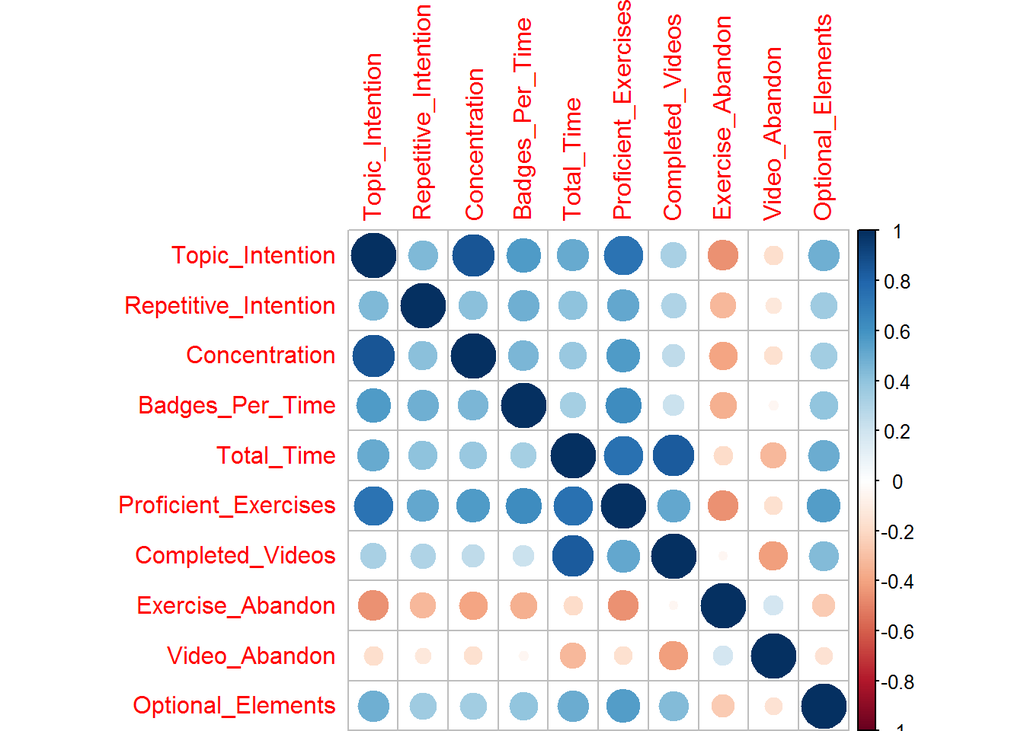

```r
corMatrix <- cor(x = differentStudents[,c("Topic_Intention", "Repetitive_Intention", "Concentration", "Badges_Per_Time", "Total_Time", "Proficient_Exercises", "Completed_Videos", "Exercise_Abandon", "Video_Abandon", "Optional_Elements")])
corrplot(corMatrix, method = "circle")
```